# Fun With Khazalid

For my final project, I would like to explore an *imagined language* called **Khazalid** spoken by the dwarves in the *Warhammer Fantasy*. The imagined universe was created early in 1983 as a tabletop game, and from then on many novels, comics, and video games about Warhammer Fantasy were created and many of them featured dwarves and their language Khazalid. Therefore, although Khazalid is an imagined language, there are many sources available about its grammar, pronunciation, writing, and lexicon.

[figure not shown]

The project features an alphabet translator, an Khazalid-to-English translator, and a Khazalid text generator.

## Alphabet Translation

Khazalid has its own writing called **Klinkarhun** (See image below). Most Khazalid texts online are still using the English alphabet. This alphabet translator aims at providing a mysterious feeling about this imagined language.

[figure not shown]

On my computer, there is one png image corresponding to each alphabet. The function below takes in a list of image names, and displays the corresponding images.

```python
from matplotlib.pyplot import figure, imshow, axis
from matplotlib.image import imread

def show_klinkarhun(ks):
    folder="klinkarhun"
    kslen = len(ks)
    factor = 0.5
    fig = figure(figsize = (kslen*factor,1*factor))

    for i, k in enumerate(ks):
        file = folder + '/' + k.lower() + '.png'
        a = fig.add_subplot(1,kslen,i+1)
        image = imread(file)
        imshow(image, cmap='Greys_r')
        axis('off')

show_klinkarhun("A Ak B Z W K".split())
```

[output not shown]

The code below implements the alphabet translation. It takes in English characters and returns a list of image names, which can then be fed into the function above in order to display the Klinkarhun.

The alphabet translation does not use a FST. It implements a *greedy* translator. It is greedy in a sense that it will check the longest prefix that matches a rule and then apply that rule. The translator is conceptually simpler than FST and easier to implement.

```python
alphabetmap = [
    ('Ak', 'Ak'),
    ('Az', 'Az'),
    ('A', 'A'),
    ('I', 'I'),
    ('B', 'B'),
    ('Dr', 'Dr'),
    ('Tr', 'Dr'),
    ('D', 'D'),
    ('E', 'E'),
    ('F', 'F'),
    ('V', 'F'),
    ('G', 'G'),
    ('H', 'H'),
    ('Kh', 'K'),
    ('Kar', 'Kar'),
    ('K', 'K'),
    ('L', 'L'),
    ('M', 'M'),
    ('Ng', 'Ng'),
    ('N', 'N'),
    ('O', 'O'),
    ('R', 'R'),
    ('Th', 'Th'),
    ('T', 'T'),
    ('W', 'W'),
    ('U', 'W'),
    ('Zh', 'Z'),
    ('Z', 'Z'),
    (' ', 'space'),
    ('S', 'Z'),
    ('ck', 'K'),
    ("'", ''),
    ('-', 'space'),
    ('y','A'),
    ('c', 'z'),
    ('p', 'b'),
]

def transduce_klinkarhun(xs):
    originalxs = "".join(list(xs))
    ys = []
    xs = xs.lower()
    while xs:
        for (k, v) in alphabetmap:
            k = k.lower()
            v = v.lower()
            if xs.startswith(k):
                xs = xs[len(k):]
                y = v
                break
        else:
            print(f'no rules apply \n{xs}\n{originalxs}')
            assert(0)
        ys.append(y)
    return ys

for x in "Gorog or an guz gorog".split():
    show_klinkarhun(transduce_klinkarhun(x))
```

[output not shown]

## CFG-based Khazalid Generator

Khazalid grammar is very similar to the SVO structure of English. Most of words in Khazalid are nouns that represent concrete objects, but there are some rules that lead to some variation (such as a change in part of speech and tense):

- plural suffix: `-i`
- noun-to-verb (present-tense) suffix: `-it`
- noun-to-verb (past-tense) suffix: `-ed`
- noun-to-verb (future-tense) prefix and suffix pair: `an-` + noun root + `-it`
- noun-to-verb (complete-perfect-tense) prefix and suffix pair: `ad` + noun root + `et`
- noun-to-verb (future-perfect-tense) prefix and suffix pair: `anad` + noun root + `et`

Despite all these variations, Khazalid grammar is simpler and results in a smaller CFG, due to a smaller set of prepositions, adverbs, and adjectives and the lack of infinitive and determiner. The code below defines a base grammar which I will procedually add in rules from an external text file.

```python
khazalid_cfg_base = {
    'S': [],
    'NP': [],
    'PP': [],
    'VP': [],
    'ADV': [],
    'ADJ': [],
    'V': [],
    'VI': [],
    'N': [],
    'P': [],
    'TENSE': [],
}
khazalid_cfg_base
```

```
{'S': [],
 'NP': [],
 'PP': [],
 'VP': [],
 'ADV': [],
 'ADJ': [],
 'V': [],
 'VI': [],
 'N': [],
 'P': [],
 'TENSE': []}
```

The code section below implements the generation function based on the CFG and is taken and adapted from the lecture.

```python
import random

def gen(g,init):
    if init not in g:
        return [init]
    else:
        output = []
        if len(g[init]) == 0:
            print(init, 'has no productions')
            return []
        rhs = random.choice(g[init])
        for i in rhs:
            x = gen(g,i)
            if x != '':
                output.extend(x)
        return output

gen(khazalid_cfg_base, 'S')
```

```
S has no productions
```

```
[]
```

The code below first adds a couple of rules, and then extend the grammer through an external dictionary.

There is a list of khazalid words online, which I downloaded into a local file in my computer and marked part of speech for each of them. The program below parses that file and add each word into V, N, P, ADJ, ADV, or TENSE.

```python
for k in khazalid_cfg_base:
    khazalid_cfg_base[k] = []
khazalid_cfg_base['S'].append(['NP', 'TENSE', 'VP'])
khazalid_cfg_base['S'].append(['NP', 'VP'])
khazalid_cfg_base['NP'].append(['N'])
khazalid_cfg_base['NP'].append(['ADJ', 'N'])
khazalid_cfg_base['NP'].append(['N', 'PP'])
khazalid_cfg_base['PP'].append(['P', 'NP'])
khazalid_cfg_base['VP'].append(['V', 'NP'])
khazalid_cfg_base['VP'].append(['V', 'NP', 'ADV'])
khazalid_cfg_base['VP'].append(['V', 'NP', 'ADV', 'PP'])
khazalid_cfg_base['VP'].append(['V', 'NP', 'PP'])
print(khazalid_cfg_base)

khazalid_cfg = khazalid_cfg_base
with open("khazalid.txt", "r") as file:
    lines = file.readlines()
    for line in lines:
        sp = line.split(';')
        if len(line) == 0 or len(sp) < 3: continue
        pos, word = sp[0].strip(), sp[1].strip()
        khazalid_cfg[pos].append([word])
```

```
{'S': [['NP', 'TENSE', 'VP'], ['NP', 'VP']], 'NP': [['N'], ['ADJ', 'N'], ['N', 'PP']], 'PP': [['P', 'NP']], 'VP': [['V', 'NP'], ['V', 'NP', 'ADV'], ['V', 'NP', 'ADV', 'PP'], ['V', 'NP', 'PP']], 'ADV': [], 'ADJ': [], 'V': [], 'VI': [], 'N': [], 'P': [], 'TENSE': []}
```

Now let us see the generation in action! First we use the `gen` function to get a sentence (a list of words)

```python
sentence = gen(khazalid_cfg, 'S')
print(sentence)
```

```
['Rhun', 'Bin', 'Maraz', 'Bezek', 'Lok', 'Gazan', 'Nu']
```

Then we use `transduce_klinkarhun` to do alphabet translation and get a list of image names, which we then feed into `show_klinkarhun` to view the symbols. The following function packs the aforementioned two functions together.

```
oneline version:
```

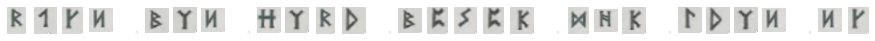

```python
def show_eng_sentence(s, oneline=False):
    if oneline:
        imgs = transduce_klinkarhun(" ".join(s))
        show_klinkarhun(imgs)
    else:
        for word in s:
            imgs = transduce_klinkarhun(word)
            show_klinkarhun(imgs)
print('oneline version:')
show_eng_sentence(sentence, oneline=True)
```

```python
print('multi-line version:')
show_eng_sentence(sentence, oneline=False)
```

[output not shown]

[output not shown]

## Khazalid-to-English Translator

Now we can generate khazalid, and let us know its meaning. The goal is to, given a khazalid sentence in English alphabet, output its English translation. To do so, I parse the external Khazalid dictionary to get an equivalent English word for each Khazalid word. Since Khazalid grammar is a subset of English grammar, translation can be as simple as word-by-word.

First let us parse the dictionary:

```python
kha2eng = dict()
with open("khazalid.txt", "r") as file:
    lines = file.readlines()
    for line in lines:
        sp = line.split(';')
        if len(line) == 0 or len(sp) < 3: continue
        word, meaning = sp[1].strip().lower(), sp[2].strip().lower()
        kha2eng[word] = meaning
list(kha2eng.items())[:20]
```

```
[('a', 'with'),
 ('af', 'you'),
 ('ad', 'did'),
 ('agril', 'silver'),
 ('agrul', 'stone carving'),
 ('ald', 'old'),
 ('aldrhun', 'old runes'),
 ('an', 'shall'),
 ('anad', 'shall have done'),
 ('angaz', 'ironwork'),
 ('ang', 'ironwork'),
 ('ankor', 'realm'),
 ('anu', 'very soon'),
 ('argul', 'stone carving'),
 ('arkhandrazkal', 'rune inscribing'),
 ('az', 'war axe'),
 ('az-dreugi', 'great axe'),
 ('azgal', 'treasure hoard'),
 ('azkahr', 'massive masonry'),
 ('azril', 'silvery colour')]
```

The following function does the word-by-word translation:

```python
def translate(kha):
    eng = [kha2eng[k.lower()] for k in kha]
    eng[0] = eng[0].capitalize()
    return eng
translate("or an guz gorog".split())
```

```
['I', 'shall', 'consume', 'ale']
```

Let us behold the final product: let us generate a Khazalid poem that consists of 5 sentences along with its english translation:

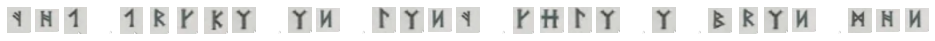

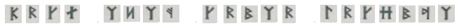

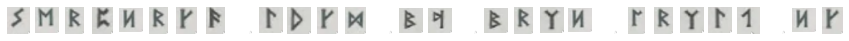

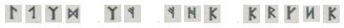

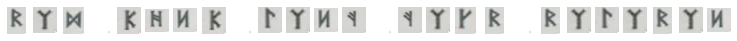

```python
translation = []
for _ in range(5):
    kha = gen(khazalid_cfg, 'S')
    show_eng_sentence(kha, oneline=True)
    translation.append(translate(kha))
```

```python
for s in translation:
    print(" ".join(s))
```

```
Stupid breed of mountain goat shall discover humans with clever thunder
Discomfiting disease contracted from mountain goats shall have done trade whiner
Bright blue ancestor god and protector of the dead punch clever tribute at this time
Skull did behold disaster
Shiny large and bulbous nose discover reliable coarse and uncomfortable clothing made from troll hide
```